# Risk Factor Analysis

## Outcome Variable

**Outcome Variable:** swasted

## Predictor Variables

**Intervention Variable:** mage

**Adjustment Set:**

unadjusted

## Stratifying Variables

The analysis was stratified on these variable(s):

- agecat
- studyid
- country

## Data Summary

| agecat | studyid | country | mage | swasted | n_cell | n |
| --- | --- | --- | --- | --- | --- | --- |
| Birth | ki0047075b-MAL-ED | BANGLADESH | [20-30) | 0 | 142 | 215 |
| Birth | ki0047075b-MAL-ED | BANGLADESH | [20-30) | 1 | 6 | 215 |
| Birth | ki0047075b-MAL-ED | BANGLADESH | <20 | 0 | 28 | 215 |
| Birth | ki0047075b-MAL-ED | BANGLADESH | <20 | 1 | 0 | 215 |
| Birth | ki0047075b-MAL-ED | BANGLADESH | >=30 | 0 | 37 | 215 |
| Birth | ki0047075b-MAL-ED | BANGLADESH | >=30 | 1 | 2 | 215 |
| Birth | ki0047075b-MAL-ED | BRAZIL | [20-30) | 0 | 39 | 62 |
| Birth | ki0047075b-MAL-ED | BRAZIL | [20-30) | 1 | 0 | 62 |
| Birth | ki0047075b-MAL-ED | BRAZIL | <20 | 0 | 8 | 62 |
| Birth | ki0047075b-MAL-ED | BRAZIL | <20 | 1 | 0 | 62 |
| Birth | ki0047075b-MAL-ED | BRAZIL | >=30 | 0 | 15 | 62 |
| Birth | ki0047075b-MAL-ED | BRAZIL | >=30 | 1 | 0 | 62 |
| Birth | ki0047075b-MAL-ED | INDIA | [20-30) | 0 | 36 | 45 |
| Birth | ki0047075b-MAL-ED | INDIA | [20-30) | 1 | 0 | 45 |
| Birth | ki0047075b-MAL-ED | INDIA | <20 | 0 | 7 | 45 |
| Birth | ki0047075b-MAL-ED | INDIA | <20 | 1 | 0 | 45 |
| Birth | ki0047075b-MAL-ED | INDIA | >=30 | 0 | 2 | 45 |
| Birth | ki0047075b-MAL-ED | INDIA | >=30 | 1 | 0 | 45 |
| Birth | ki0047075b-MAL-ED | NEPAL | [20-30) | 0 | 20 | 26 |
| Birth | ki0047075b-MAL-ED | NEPAL | [20-30) | 1 | 1 | 26 |
| Birth | ki0047075b-MAL-ED | NEPAL | <20 | 0 | 0 | 26 |
| Birth | ki0047075b-MAL-ED | NEPAL | <20 | 1 | 0 | 26 |
| Birth | ki0047075b-MAL-ED | NEPAL | >=30 | 0 | 5 | 26 |
| Birth | ki0047075b-MAL-ED | NEPAL | >=30 | 1 | 0 | 26 |
| Birth | ki0047075b-MAL-ED | PERU | [20-30) | 0 | 113 | 228 |
| Birth | ki0047075b-MAL-ED | PERU | [20-30) | 1 | 0 | 228 |
| Birth | ki0047075b-MAL-ED | PERU | <20 | 0 | 63 | 228 |
| Birth | ki0047075b-MAL-ED | PERU | <20 | 1 | 0 | 228 |
| Birth | ki0047075b-MAL-ED | PERU | >=30 | 0 | 52 | 228 |
| Birth | ki0047075b-MAL-ED | PERU | >=30 | 1 | 0 | 228 |

[output cut: 396 more lines]

The following strata were considered:

- agecat: 24 months, studyid: ki0047075b-MAL-ED, country: BANGLADESH
- agecat: 24 months, studyid: ki0047075b-MAL-ED, country: BRAZIL
- agecat: 24 months, studyid: ki0047075b-MAL-ED, country: INDIA
- agecat: 24 months, studyid: ki0047075b-MAL-ED, country: NEPAL
- agecat: 24 months, studyid: ki0047075b-MAL-ED, country: PERU
- agecat: 24 months, studyid: ki0047075b-MAL-ED, country: SOUTH AFRICA
- agecat: 24 months, studyid: ki0047075b-MAL-ED, country: TANZANIA, UNITED REPUBLIC OF
- agecat: 24 months, studyid: ki1000108-CMC-V-BCS-2002, country: INDIA
- agecat: 24 months, studyid: ki1000108-IRC, country: INDIA
- agecat: 24 months, studyid: ki1000109-EE, country: PAKISTAN
- agecat: 24 months, studyid: ki1017093-NIH-Birth, country: BANGLADESH
- agecat: 24 months, studyid: ki1017093b-PROVIDE, country: BANGLADESH
- agecat: 24 months, studyid: ki1017093c-NIH-Crypto, country: BANGLADESH
- agecat: 24 months, studyid: ki1066203-TanzaniaChild2, country: TANZANIA, UNITED REPUBLIC OF
- agecat: 24 months, studyid: ki1101329-Keneba, country: GAMBIA
- agecat: 24 months, studyid: ki1113344-GMS-Nepal, country: NEPAL
- agecat: 24 months, studyid: ki1119695-PROBIT, country: BELARUS
- agecat: 24 months, studyid: ki1126311-ZVITAMBO, country: ZIMBABWE
- agecat: 24 months, studyid: ki1135781-COHORTS, country: GUATEMALA
- agecat: 24 months, studyid: ki1135781-COHORTS, country: INDIA
- agecat: 24 months, studyid: ki1135781-COHORTS, country: PHILIPPINES
- agecat: 24 months, studyid: ki1148112-LCNI-5, country: MALAWI
- agecat: 24 months, studyid: kiGH5241-JiVitA-3, country: BANGLADESH
- agecat: 6 months, studyid: ki0047075b-MAL-ED, country: BANGLADESH
- agecat: 6 months, studyid: ki0047075b-MAL-ED, country: BRAZIL
- agecat: 6 months, studyid: ki0047075b-MAL-ED, country: INDIA
- agecat: 6 months, studyid: ki0047075b-MAL-ED, country: NEPAL
- agecat: 6 months, studyid: ki0047075b-MAL-ED, country: PERU
- agecat: 6 months, studyid: ki0047075b-MAL-ED, country: SOUTH AFRICA
- agecat: 6 months, studyid: ki0047075b-MAL-ED, country: TANZANIA, UNITED REPUBLIC OF
- agecat: 6 months, studyid: ki1000108-CMC-V-BCS-2002, country: INDIA
- agecat: 6 months, studyid: ki1000108-IRC, country: INDIA
- agecat: 6 months, studyid: ki1000109-EE, country: PAKISTAN
- agecat: 6 months, studyid: ki1000304b-SAS-CompFeed, country: INDIA
- agecat: 6 months, studyid: ki1000304b-SAS-FoodSuppl, country: INDIA
- agecat: 6 months, studyid: ki1017093-NIH-Birth, country: BANGLADESH
- agecat: 6 months, studyid: ki1017093b-PROVIDE, country: BANGLADESH
- agecat: 6 months, studyid: ki1017093c-NIH-Crypto, country: BANGLADESH
- agecat: 6 months, studyid: ki1066203-TanzaniaChild2, country: TANZANIA, UNITED REPUBLIC OF
- agecat: 6 months, studyid: ki1101329-Keneba, country: GAMBIA
- agecat: 6 months, studyid: ki1112895-Guatemala BSC, country: GUATEMALA
- agecat: 6 months, studyid: ki1113344-GMS-Nepal, country: NEPAL
- agecat: 6 months, studyid: ki1119695-PROBIT, country: BELARUS
- agecat: 6 months, studyid: ki1126311-ZVITAMBO, country: ZIMBABWE
- agecat: 6 months, studyid: ki1135781-COHORTS, country: GUATEMALA
- agecat: 6 months, studyid: ki1135781-COHORTS, country: INDIA
- agecat: 6 months, studyid: ki1135781-COHORTS, country: PHILIPPINES
- agecat: 6 months, studyid: ki1148112-LCNI-5, country: MALAWI
- agecat: 6 months, studyid: kiGH5241-JiVitA-3, country: BANGLADESH
- agecat: Birth, studyid: ki0047075b-MAL-ED, country: BANGLADESH
- agecat: Birth, studyid: ki0047075b-MAL-ED, country: BRAZIL
- agecat: Birth, studyid: ki0047075b-MAL-ED, country: INDIA
- agecat: Birth, studyid: ki0047075b-MAL-ED, country: NEPAL
- agecat: Birth, studyid: ki0047075b-MAL-ED, country: PERU
- agecat: Birth, studyid: ki0047075b-MAL-ED, country: SOUTH AFRICA
- agecat: Birth, studyid: ki0047075b-MAL-ED, country: TANZANIA, UNITED REPUBLIC OF
- agecat: Birth, studyid: ki1000108-CMC-V-BCS-2002, country: INDIA
- agecat: Birth, studyid: ki1000108-IRC, country: INDIA
- agecat: Birth, studyid: ki1000109-EE, country: PAKISTAN
- agecat: Birth, studyid: ki1000304b-SAS-CompFeed, country: INDIA
- agecat: Birth, studyid: ki1017093-NIH-Birth, country: BANGLADESH
- agecat: Birth, studyid: ki1017093b-PROVIDE, country: BANGLADESH
- agecat: Birth, studyid: ki1017093c-NIH-Crypto, country: BANGLADESH
- agecat: Birth, studyid: ki1101329-Keneba, country: GAMBIA
- agecat: Birth, studyid: ki1113344-GMS-Nepal, country: NEPAL
- agecat: Birth, studyid: ki1119695-PROBIT, country: BELARUS
- agecat: Birth, studyid: ki1126311-ZVITAMBO, country: ZIMBABWE
- agecat: Birth, studyid: ki1135781-COHORTS, country: GUATEMALA
- agecat: Birth, studyid: ki1135781-COHORTS, country: INDIA
- agecat: Birth, studyid: ki1135781-COHORTS, country: PHILIPPINES
- agecat: Birth, studyid: kiGH5241-JiVitA-3, country: BANGLADESH

### Dropped Strata

Some strata were dropped due to rare outcomes:

- agecat: Birth, studyid: ki0047075b-MAL-ED, country: BANGLADESH
- agecat: Birth, studyid: ki0047075b-MAL-ED, country: BRAZIL
- agecat: Birth, studyid: ki0047075b-MAL-ED, country: INDIA
- agecat: Birth, studyid: ki0047075b-MAL-ED, country: NEPAL
- agecat: Birth, studyid: ki0047075b-MAL-ED, country: PERU
- agecat: Birth, studyid: ki0047075b-MAL-ED, country: SOUTH AFRICA
- agecat: Birth, studyid: ki0047075b-MAL-ED, country: TANZANIA, UNITED REPUBLIC OF
- agecat: Birth, studyid: ki1000108-CMC-V-BCS-2002, country: INDIA
- agecat: Birth, studyid: ki1000108-IRC, country: INDIA
- agecat: Birth, studyid: ki1000109-EE, country: PAKISTAN
- agecat: Birth, studyid: ki1000304b-SAS-CompFeed, country: INDIA
- agecat: Birth, studyid: ki1017093-NIH-Birth, country: BANGLADESH
- agecat: Birth, studyid: ki1017093b-PROVIDE, country: BANGLADESH
- agecat: Birth, studyid: ki1113344-GMS-Nepal, country: NEPAL
- agecat: 6 months, studyid: ki0047075b-MAL-ED, country: BANGLADESH
- agecat: 6 months, studyid: ki0047075b-MAL-ED, country: BRAZIL
- agecat: 6 months, studyid: ki0047075b-MAL-ED, country: INDIA
- agecat: 6 months, studyid: ki0047075b-MAL-ED, country: NEPAL
- agecat: 6 months, studyid: ki0047075b-MAL-ED, country: PERU
- agecat: 6 months, studyid: ki0047075b-MAL-ED, country: SOUTH AFRICA
- agecat: 6 months, studyid: ki0047075b-MAL-ED, country: TANZANIA, UNITED REPUBLIC OF
- agecat: 6 months, studyid: ki1000108-CMC-V-BCS-2002, country: INDIA
- agecat: 6 months, studyid: ki1000108-IRC, country: INDIA
- agecat: 6 months, studyid: ki1000109-EE, country: PAKISTAN
- agecat: 6 months, studyid: ki1000304b-SAS-CompFeed, country: INDIA
- agecat: 6 months, studyid: ki1000304b-SAS-FoodSuppl, country: INDIA
- agecat: 6 months, studyid: ki1017093-NIH-Birth, country: BANGLADESH
- agecat: 6 months, studyid: ki1017093b-PROVIDE, country: BANGLADESH
- agecat: 6 months, studyid: ki1017093c-NIH-Crypto, country: BANGLADESH
- agecat: 6 months, studyid: ki1066203-TanzaniaChild2, country: TANZANIA, UNITED REPUBLIC OF
- agecat: 6 months, studyid: ki1112895-Guatemala BSC, country: GUATEMALA
- agecat: 6 months, studyid: ki1113344-GMS-Nepal, country: NEPAL
- agecat: 6 months, studyid: ki1119695-PROBIT, country: BELARUS
- agecat: 6 months, studyid: ki1135781-COHORTS, country: GUATEMALA
- agecat: 6 months, studyid: ki1148112-LCNI-5, country: MALAWI
- agecat: 24 months, studyid: ki0047075b-MAL-ED, country: BANGLADESH
- agecat: 24 months, studyid: ki0047075b-MAL-ED, country: BRAZIL
- agecat: 24 months, studyid: ki0047075b-MAL-ED, country: INDIA
- agecat: 24 months, studyid: ki0047075b-MAL-ED, country: NEPAL
- agecat: 24 months, studyid: ki0047075b-MAL-ED, country: PERU
- agecat: 24 months, studyid: ki0047075b-MAL-ED, country: SOUTH AFRICA
- agecat: 24 months, studyid: ki0047075b-MAL-ED, country: TANZANIA, UNITED REPUBLIC OF
- agecat: 24 months, studyid: ki1000108-CMC-V-BCS-2002, country: INDIA
- agecat: 24 months, studyid: ki1000108-IRC, country: INDIA
- agecat: 24 months, studyid: ki1000109-EE, country: PAKISTAN
- agecat: 24 months, studyid: ki1017093-NIH-Birth, country: BANGLADESH
- agecat: 24 months, studyid: ki1017093b-PROVIDE, country: BANGLADESH
- agecat: 24 months, studyid: ki1017093c-NIH-Crypto, country: BANGLADESH
- agecat: 24 months, studyid: ki1066203-TanzaniaChild2, country: TANZANIA, UNITED REPUBLIC OF
- agecat: 24 months, studyid: ki1101329-Keneba, country: GAMBIA
- agecat: 24 months, studyid: ki1113344-GMS-Nepal, country: NEPAL
- agecat: 24 months, studyid: ki1119695-PROBIT, country: BELARUS
- agecat: 24 months, studyid: ki1126311-ZVITAMBO, country: ZIMBABWE
- agecat: 24 months, studyid: ki1135781-COHORTS, country: GUATEMALA
- agecat: 24 months, studyid: ki1135781-COHORTS, country: INDIA
- agecat: 24 months, studyid: ki1135781-COHORTS, country: PHILIPPINES
- agecat: 24 months, studyid: ki1148112-LCNI-5, country: MALAWI

## Methods Detail

We’re interested in the causal parameters $E[Y_a]$ for all values of $a \in \mathcal{A}$. These parameters represent the mean outcome if, possibly contrary to fact, we intervened to set all units to have $A=a$. Under the randomization and positivity assumptions, these are identified by the statistical parameters $\psi_a=E_W[E_{Y|A,W}(Y|A=a,W)]$. In addition, we’re interested in the mean of $Y$, $E[Y]$ under no intervention (the observed mean). We will estimate these parameters by using SuperLearner to fit the relevant likelihood factors – $E_{Y|A,W}(Y|A=a,W)$ and $p(A=a|W)$, and then updating our likelihood fit using a joint TMLE.

For unadjusted analyses ($W=\{\}$), initial likelihoods were estimated using Lrnr_glm to estimate the simple $E(Y|A)$ and Lrnr_mean to estimate $p(A)$. For adjusted analyses, a small library containing Lrnr_glmnet, Lrnr_xgboost, and Lrnr_mean was used.

Having estimated these parameters, we will then use the delta method to estimate relative risks and attributable risks relative to a prespecified baseline level of $A$.

# Results Detail

## Results Plots

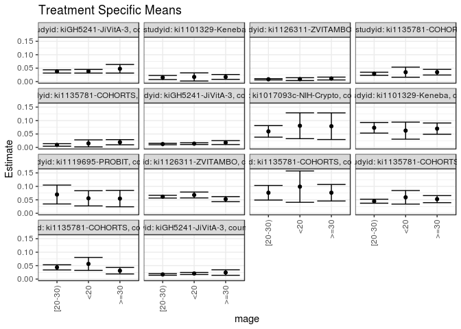

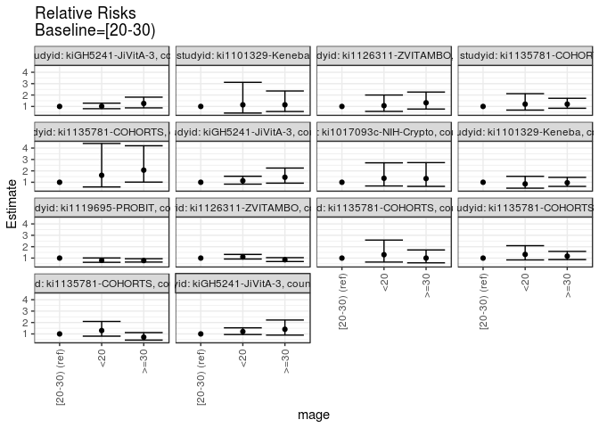

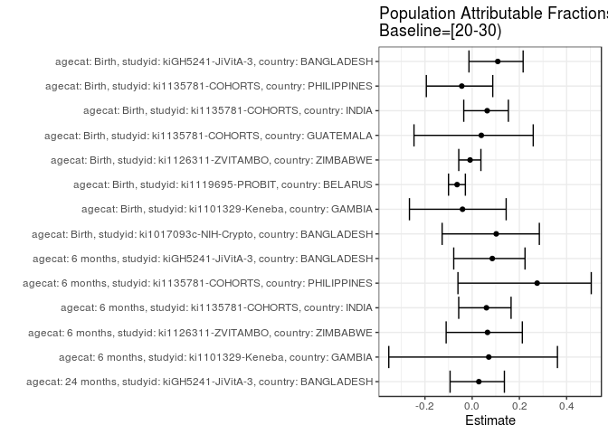

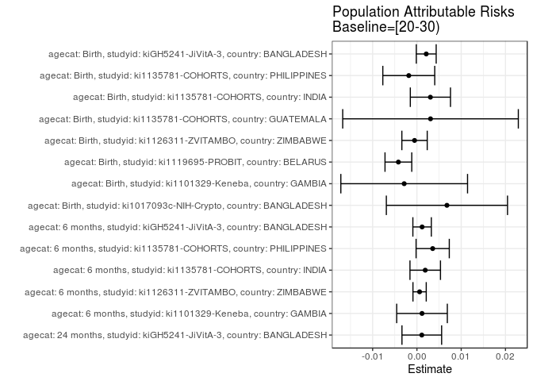

## Results Table

### Parameter: TSM

| agecat | studyid | country | intervention_level | baseline_level | estimate | ci_lower | ci_upper |
| --- | --- | --- | --- | --- | --- | --- | --- |
| Birth | ki1017093c-NIH-Crypto | BANGLADESH | [20-30) | NA | 0.0597015 | 0.0382432 | 0.0811598 |
| Birth | ki1017093c-NIH-Crypto | BANGLADESH | <20 | NA | 0.0806452 | 0.0326856 | 0.1286047 |
| Birth | ki1017093c-NIH-Crypto | BANGLADESH | >=30 | NA | 0.0789474 | 0.0294122 | 0.1284826 |
| Birth | ki1101329-Keneba | GAMBIA | [20-30) | NA | 0.0731343 | 0.0534134 | 0.0928553 |
| Birth | ki1101329-Keneba | GAMBIA | <20 | NA | 0.0625000 | 0.0307899 | 0.0942101 |
| Birth | ki1101329-Keneba | GAMBIA | >=30 | NA | 0.0699301 | 0.0490232 | 0.0908369 |
| Birth | ki1119695-PROBIT | BELARUS | [20-30) | NA | 0.0696970 | 0.0346665 | 0.1047275 |
| Birth | ki1119695-PROBIT | BELARUS | <20 | NA | 0.0556348 | 0.0273595 | 0.0839101 |
| Birth | ki1119695-PROBIT | BELARUS | >=30 | NA | 0.0545886 | 0.0240462 | 0.0851310 |
| Birth | ki1126311-ZVITAMBO | ZIMBABWE | [20-30) | NA | 0.0616359 | 0.0565764 | 0.0666954 |
| Birth | ki1126311-ZVITAMBO | ZIMBABWE | <20 | NA | 0.0679803 | 0.0570301 | 0.0789305 |
| Birth | ki1126311-ZVITAMBO | ZIMBABWE | >=30 | NA | 0.0525104 | 0.0431273 | 0.0618934 |
| Birth | ki1135781-COHORTS | GUATEMALA | [20-30) | NA | 0.0762943 | 0.0491164 | 0.1034721 |
| Birth | ki1135781-COHORTS | GUATEMALA | <20 | NA | 0.0990099 | 0.0407226 | 0.1572972 |
| Birth | ki1135781-COHORTS | GUATEMALA | >=30 | NA | 0.0763889 | 0.0456917 | 0.1070861 |
| Birth | ki1135781-COHORTS | INDIA | [20-30) | NA | 0.0448567 | 0.0374053 | 0.0523080 |
| Birth | ki1135781-COHORTS | INDIA | <20 | NA | 0.0593472 | 0.0341183 | 0.0845760 |
| Birth | ki1135781-COHORTS | INDIA | >=30 | NA | 0.0525839 | 0.0394102 | 0.0657575 |
| Birth | ki1135781-COHORTS | PHILIPPINES | [20-30) | NA | 0.0435780 | 0.0339948 | 0.0531611 |
| Birth | ki1135781-COHORTS | PHILIPPINES | <20 | NA | 0.0564972 | 0.0324421 | 0.0805522 |
| Birth | ki1135781-COHORTS | PHILIPPINES | >=30 | NA | 0.0312110 | 0.0191669 | 0.0432551 |
| Birth | kiGH5241-JiVitA-3 | BANGLADESH | [20-30) | NA | 0.0172796 | 0.0142783 | 0.0202809 |
| Birth | kiGH5241-JiVitA-3 | BANGLADESH | <20 | NA | 0.0208247 | 0.0170405 | 0.0246090 |
| Birth | kiGH5241-JiVitA-3 | BANGLADESH | >=30 | NA | 0.0243196 | 0.0141425 | 0.0344967 |
| 6 months | ki1101329-Keneba | GAMBIA | [20-30) | NA | 0.0151976 | 0.0075635 | 0.0228316 |
| 6 months | ki1101329-Keneba | GAMBIA | <20 | NA | 0.0173611 | 0.0022728 | 0.0324495 |
| 6 months | ki1101329-Keneba | GAMBIA | >=30 | NA | 0.0173913 | 0.0083587 | 0.0264239 |
| 6 months | ki1126311-ZVITAMBO | ZIMBABWE | [20-30) | NA | 0.0087018 | 0.0062758 | 0.0111278 |
| 6 months | ki1126311-ZVITAMBO | ZIMBABWE | <20 | NA | 0.0092879 | 0.0040570 | 0.0145188 |
| 6 months | ki1126311-ZVITAMBO | ZIMBABWE | >=30 | NA | 0.0114943 | 0.0062146 | 0.0167739 |
| 6 months | ki1135781-COHORTS | INDIA | [20-30) | NA | 0.0291642 | 0.0234450 | 0.0348833 |
| 6 months | ki1135781-COHORTS | INDIA | <20 | NA | 0.0350404 | 0.0163274 | 0.0537535 |
| 6 months | ki1135781-COHORTS | INDIA | >=30 | NA | 0.0350000 | 0.0246008 | 0.0453992 |
| 6 months | ki1135781-COHORTS | PHILIPPINES | [20-30) | NA | 0.0093750 | 0.0046521 | 0.0140979 |
| 6 months | ki1135781-COHORTS | PHILIPPINES | <20 | NA | 0.0151057 | 0.0019632 | 0.0282483 |
| 6 months | ki1135781-COHORTS | PHILIPPINES | >=30 | NA | 0.0193548 | 0.0096536 | 0.0290561 |
| 6 months | kiGH5241-JiVitA-3 | BANGLADESH | [20-30) | NA | 0.0125392 | 0.0098656 | 0.0152127 |
| 6 months | kiGH5241-JiVitA-3 | BANGLADESH | <20 | NA | 0.0141700 | 0.0109880 | 0.0173521 |
| 6 months | kiGH5241-JiVitA-3 | BANGLADESH | >=30 | NA | 0.0180476 | 0.0107349 | 0.0253602 |
| 24 months | kiGH5241-JiVitA-3 | BANGLADESH | [20-30) | NA | 0.0378619 | 0.0319054 | 0.0438185 |
| 24 months | kiGH5241-JiVitA-3 | BANGLADESH | <20 | NA | 0.0384915 | 0.0317593 | 0.0452238 |
| 24 months | kiGH5241-JiVitA-3 | BANGLADESH | >=30 | NA | 0.0477528 | 0.0317831 | 0.0637225 |

### Parameter: E(Y)

| agecat | studyid | country | intervention_level | baseline_level | estimate | ci_lower | ci_upper |
| --- | --- | --- | --- | --- | --- | --- | --- |
| Birth | ki1017093c-NIH-Crypto | BANGLADESH | NA | NA | 0.0664781 | 0.0481022 | 0.0848539 |
| Birth | ki1101329-Keneba | GAMBIA | NA | NA | 0.0702592 | 0.0571716 | 0.0833469 |
| Birth | ki1119695-PROBIT | BELARUS | NA | NA | 0.0655098 | 0.0324802 | 0.0985393 |
| Birth | ki1126311-ZVITAMBO | ZIMBABWE | NA | NA | 0.0610977 | 0.0569614 | 0.0652340 |
| Birth | ki1135781-COHORTS | GUATEMALA | NA | NA | 0.0793651 | 0.0600839 | 0.0986462 |
| Birth | ki1135781-COHORTS | INDIA | NA | NA | 0.0479001 | 0.0415930 | 0.0542073 |
| Birth | ki1135781-COHORTS | PHILIPPINES | NA | NA | 0.0417385 | 0.0344572 | 0.0490198 |
| Birth | kiGH5241-JiVitA-3 | BANGLADESH | NA | NA | 0.0193824 | 0.0169738 | 0.0217910 |
| 6 months | ki1101329-Keneba | GAMBIA | NA | NA | 0.0163462 | 0.0108955 | 0.0217968 |
| 6 months | ki1126311-ZVITAMBO | ZIMBABWE | NA | NA | 0.0093062 | 0.0072635 | 0.0113488 |
| 6 months | ki1135781-COHORTS | INDIA | NA | NA | 0.0310394 | 0.0261816 | 0.0358972 |
| 6 months | ki1135781-COHORTS | PHILIPPINES | NA | NA | 0.0129342 | 0.0086762 | 0.0171922 |
| 6 months | kiGH5241-JiVitA-3 | BANGLADESH | NA | NA | 0.0137076 | 0.0116310 | 0.0157842 |
| 24 months | kiGH5241-JiVitA-3 | BANGLADESH | NA | NA | 0.0389625 | 0.0346386 | 0.0432864 |

### Parameter: RR

| agecat | studyid | country | intervention_level | baseline_level | estimate | ci_lower | ci_upper |
| --- | --- | --- | --- | --- | --- | --- | --- |
| Birth | ki1017093c-NIH-Crypto | BANGLADESH | [20-30) | [20-30) | 1.0000000 | 1.0000000 | 1.0000000 |
| Birth | ki1017093c-NIH-Crypto | BANGLADESH | <20 | [20-30) | 1.3508065 | 0.6742361 | 2.7062893 |
| Birth | ki1017093c-NIH-Crypto | BANGLADESH | >=30 | [20-30) | 1.3223684 | 0.6416727 | 2.7251561 |
| Birth | ki1101329-Keneba | GAMBIA | [20-30) | [20-30) | 1.0000000 | 1.0000000 | 1.0000000 |
| Birth | ki1101329-Keneba | GAMBIA | <20 | [20-30) | 0.8545918 | 0.4810904 | 1.5180665 |
| Birth | ki1101329-Keneba | GAMBIA | >=30 | [20-30) | 0.9561867 | 0.6392804 | 1.4301908 |
| Birth | ki1119695-PROBIT | BELARUS | [20-30) | [20-30) | 1.0000000 | 1.0000000 | 1.0000000 |
| Birth | ki1119695-PROBIT | BELARUS | <20 | [20-30) | 0.7982385 | 0.6305054 | 1.0105937 |
| Birth | ki1119695-PROBIT | BELARUS | >=30 | [20-30) | 0.7832278 | 0.6511345 | 0.9421185 |
| Birth | ki1126311-ZVITAMBO | ZIMBABWE | [20-30) | [20-30) | 1.0000000 | 1.0000000 | 1.0000000 |
| Birth | ki1126311-ZVITAMBO | ZIMBABWE | <20 | [20-30) | 1.1029326 | 0.9205204 | 1.3214921 |
| Birth | ki1126311-ZVITAMBO | ZIMBABWE | >=30 | [20-30) | 0.8519438 | 0.6998584 | 1.0370788 |
| Birth | ki1135781-COHORTS | GUATEMALA | [20-30) | [20-30) | 1.0000000 | 1.0000000 | 1.0000000 |
| Birth | ki1135781-COHORTS | GUATEMALA | <20 | [20-30) | 1.2977369 | 0.6521592 | 2.5823771 |
| Birth | ki1135781-COHORTS | GUATEMALA | >=30 | [20-30) | 1.0012401 | 0.5852165 | 1.7130098 |
| Birth | ki1135781-COHORTS | INDIA | [20-30) | [20-30) | 1.0000000 | 1.0000000 | 1.0000000 |
| Birth | ki1135781-COHORTS | INDIA | <20 | [20-30) | 1.3230405 | 0.8382188 | 2.0882807 |
| Birth | ki1135781-COHORTS | INDIA | >=30 | [20-30) | 1.1722643 | 0.8679181 | 1.5833331 |
| Birth | ki1135781-COHORTS | PHILIPPINES | [20-30) | [20-30) | 1.0000000 | 1.0000000 | 1.0000000 |
| Birth | ki1135781-COHORTS | PHILIPPINES | <20 | [20-30) | 1.2964615 | 0.8028619 | 2.0935263 |
| Birth | ki1135781-COHORTS | PHILIPPINES | >=30 | [20-30) | 0.7162100 | 0.4593529 | 1.1166944 |
| Birth | kiGH5241-JiVitA-3 | BANGLADESH | [20-30) | [20-30) | 1.0000000 | 1.0000000 | 1.0000000 |
| Birth | kiGH5241-JiVitA-3 | BANGLADESH | <20 | [20-30) | 1.2051635 | 0.9477589 | 1.5324774 |
| Birth | kiGH5241-JiVitA-3 | BANGLADESH | >=30 | [20-30) | 1.4074205 | 0.8931337 | 2.2178454 |
| 6 months | ki1101329-Keneba | GAMBIA | [20-30) | [20-30) | 1.0000000 | 1.0000000 | 1.0000000 |
| 6 months | ki1101329-Keneba | GAMBIA | <20 | [20-30) | 1.1423611 | 0.4186513 | 3.1171262 |
| 6 months | ki1101329-Keneba | GAMBIA | >=30 | [20-30) | 1.1443478 | 0.5555970 | 2.3569817 |
| 6 months | ki1126311-ZVITAMBO | ZIMBABWE | [20-30) | [20-30) | 1.0000000 | 1.0000000 | 1.0000000 |
| 6 months | ki1126311-ZVITAMBO | ZIMBABWE | <20 | [20-30) | 1.0673533 | 0.5693634 | 2.0009067 |
| 6 months | ki1126311-ZVITAMBO | ZIMBABWE | >=30 | [20-30) | 1.3209008 | 0.7718201 | 2.2606029 |
| 6 months | ki1135781-COHORTS | INDIA | [20-30) | [20-30) | 1.0000000 | 1.0000000 | 1.0000000 |
| 6 months | ki1135781-COHORTS | INDIA | <20 | [20-30) | 1.2014894 | 0.6802152 | 2.1222354 |
| 6 months | ki1135781-COHORTS | INDIA | >=30 | [20-30) | 1.2001031 | 0.8406398 | 1.7132754 |
| 6 months | ki1135781-COHORTS | PHILIPPINES | [20-30) | [20-30) | 1.0000000 | 1.0000000 | 1.0000000 |
| 6 months | ki1135781-COHORTS | PHILIPPINES | <20 | [20-30) | 1.6112790 | 0.5895856 | 4.4034656 |
| 6 months | ki1135781-COHORTS | PHILIPPINES | >=30 | [20-30) | 2.0645161 | 1.0143478 | 4.2019384 |
| 6 months | kiGH5241-JiVitA-3 | BANGLADESH | [20-30) | [20-30) | 1.0000000 | 1.0000000 | 1.0000000 |
| 6 months | kiGH5241-JiVitA-3 | BANGLADESH | <20 | [20-30) | 1.1300607 | 0.8358125 | 1.5278992 |
| 6 months | kiGH5241-JiVitA-3 | BANGLADESH | >=30 | [20-30) | 1.4392945 | 0.9220224 | 2.2467662 |
| 24 months | kiGH5241-JiVitA-3 | BANGLADESH | [20-30) | [20-30) | 1.0000000 | 1.0000000 | 1.0000000 |
| 24 months | kiGH5241-JiVitA-3 | BANGLADESH | <20 | [20-30) | 1.0166297 | 0.8038288 | 1.2857662 |
| 24 months | kiGH5241-JiVitA-3 | BANGLADESH | >=30 | [20-30) | 1.2612360 | 0.8765736 | 1.8146977 |

### Parameter: PAR

| agecat | studyid | country | intervention_level | baseline_level | estimate | ci_lower | ci_upper |
| --- | --- | --- | --- | --- | --- | --- | --- |
| Birth | ki1017093c-NIH-Crypto | BANGLADESH | [20-30) | NA | 0.0067766 | -0.0069064 | 0.0204596 |
| Birth | ki1101329-Keneba | GAMBIA | [20-30) | NA | -0.0028751 | -0.0171829 | 0.0114327 |
| Birth | ki1119695-PROBIT | BELARUS | [20-30) | NA | -0.0041872 | -0.0072084 | -0.0011660 |
| Birth | ki1126311-ZVITAMBO | ZIMBABWE | [20-30) | NA | -0.0005382 | -0.0034031 | 0.0023267 |
| Birth | ki1135781-COHORTS | GUATEMALA | [20-30) | NA | 0.0030708 | -0.0167599 | 0.0229015 |
| Birth | ki1135781-COHORTS | INDIA | [20-30) | NA | 0.0030435 | -0.0014907 | 0.0075776 |
| Birth | ki1135781-COHORTS | PHILIPPINES | [20-30) | NA | -0.0018395 | -0.0077011 | 0.0040222 |
| Birth | kiGH5241-JiVitA-3 | BANGLADESH | [20-30) | NA | 0.0021029 | -0.0001440 | 0.0043497 |
| 6 months | ki1101329-Keneba | GAMBIA | [20-30) | NA | 0.0011486 | -0.0045680 | 0.0068652 |
| 6 months | ki1126311-ZVITAMBO | ZIMBABWE | [20-30) | NA | 0.0006043 | -0.0008957 | 0.0021043 |
| 6 months | ki1135781-COHORTS | INDIA | [20-30) | NA | 0.0018753 | -0.0015709 | 0.0053214 |
| 6 months | ki1135781-COHORTS | PHILIPPINES | [20-30) | NA | 0.0035592 | -0.0001903 | 0.0073087 |
| 6 months | kiGH5241-JiVitA-3 | BANGLADESH | [20-30) | NA | 0.0011684 | -0.0009154 | 0.0032523 |
| 24 months | kiGH5241-JiVitA-3 | BANGLADESH | [20-30) | NA | 0.0011006 | -0.0033798 | 0.0055811 |

### Parameter: PAF

| agecat | studyid | country | intervention_level | baseline_level | estimate | ci_lower | ci_upper |
| --- | --- | --- | --- | --- | --- | --- | --- |
| Birth | ki1017093c-NIH-Crypto | BANGLADESH | [20-30) | NA | 0.1019371 | -0.1272656 | 0.2845369 |
| Birth | ki1101329-Keneba | GAMBIA | [20-30) | NA | -0.0409216 | -0.2657038 | 0.1439405 |
| Birth | ki1119695-PROBIT | BELARUS | [20-30) | NA | -0.0639173 | -0.1002020 | -0.0288293 |
| Birth | ki1126311-ZVITAMBO | ZIMBABWE | [20-30) | NA | -0.0088089 | -0.0568034 | 0.0370059 |
| Birth | ki1135781-COHORTS | GUATEMALA | [20-30) | NA | 0.0386921 | -0.2464632 | 0.2586120 |
| Birth | ki1135781-COHORTS | INDIA | [20-30) | NA | 0.0635375 | -0.0356998 | 0.1532661 |
| Birth | ki1135781-COHORTS | PHILIPPINES | [20-30) | NA | -0.0440708 | -0.1941718 | 0.0871633 |
| Birth | kiGH5241-JiVitA-3 | BANGLADESH | [20-30) | NA | 0.1084928 | -0.0135709 | 0.2158564 |
| 6 months | ki1101329-Keneba | GAMBIA | [20-30) | NA | 0.0702664 | -0.3532073 | 0.3612179 |
| 6 months | ki1126311-ZVITAMBO | ZIMBABWE | [20-30) | NA | 0.0649389 | -0.1102350 | 0.2124737 |
| 6 months | ki1135781-COHORTS | INDIA | [20-30) | NA | 0.0604152 | -0.0570087 | 0.1647943 |
| 6 months | ki1135781-COHORTS | PHILIPPINES | [20-30) | NA | 0.2751786 | -0.0602189 | 0.5044739 |
| 6 months | kiGH5241-JiVitA-3 | BANGLADESH | [20-30) | NA | 0.0852392 | -0.0781253 | 0.2238497 |
| 24 months | kiGH5241-JiVitA-3 | BANGLADESH | [20-30) | NA | 0.0282485 | -0.0935747 | 0.1365007 |